# Hrvatska u kontekstu europskih konvergencijskih klubova

Luka Sikic

Croatian Catholic University  
luka.sikic@unicath.hr

2025-04-28

Abstract

# 1 Uvod

Dohodovna konvergencija predstavlja ključni aspekt ekonomske integracije i razvoja, posebno unutar Europske unije koja teži smanjenju ekonomskih dispariteta među svojim članicama. Za Hrvatsku, kao najnoviju članicu EU, razumijevanje dinamike dohodovne konvergencije je od posebne važnosti. Ovo istraživanje ima za cilj analizirati pripadnost Hrvatske različitim konvergencijskim klubovima unutar EU te utvrditi u kojoj mjeri Hrvatska smanjuje dohodovni jaz s drugim zemljama članicama.U radu istražuje se dohodovna konvergencija Hrvatske prema različitim skupinama europskih zemalja: stare članice EU (EU15), nove članice iz srednje i istočne Europe (NMS8 i NMS12) te zemlje južne Europe (SE4). Korištenjem metoda vremenskih serija i frakcijske integracije, istraživanje pruža uvid u konvergencijske procese koji oblikuju ekonomski položaj Hrvatske unutar EU.

U nastavku rada pruža se pregled ključnih aspekata literature o dohodovnoj konvergenciji te pregled radova koji su analizirali konvergenciju dohotka u europskim posttranzicijskim zemljama. U trećem dijelu opisuju se koncepti dohodovne konvergencije u okviru analize vremenskih serija te se detaljno prikazuje metodologija frakcijske integracije i korišteni procjenitelji. Četvrti dio donosi stilizirane činjenice o konvergencijskom procesu Republike Hrvatske prema dohodovnim razinama skupina EU15, NMS8, NMS12 i SE4, dok su u petom dijelu prikazani rezultati istraživanja. U zaključku se sumiraju glavne spoznaje analize.

# 2 Pregled literature o dohodovnoj konvergenciji

Rana literatura o konvergenciji prvenstveno se usmjeravala na provjeru ekonomske teorije rasta (Barro i Sala-i-Martin, 1990, 1991; Barro, 1991; Mankiw i sur., 1992) koristeći uglavnom prostornu (eng. cross-section) regresijsku analizu. Neki autori primijenili su različite procjenitelje za panel-podatke (Knight i sur., 1993; Islam, 1995; Caselli i sur., 1996; Lee i sur., 1998; Bond i sur., 2001). Općenito, rezultati su potvrdili postojanje apsolutne ili uvjetne konvergencije u globalnim uzorcima zemalja, pri čemu su procijenjene stope konvergencije iznosile između 2% i 4%. Ipak, nije uspostavljen jedinstven konsenzus o globalnoj dohodovnoj konvergenciji.

U kasnijoj fazi, naglasak se pomaknuo na primjenu različitih metoda testiranja dohodovne konvergencije. Bernard i Durlauf (1991) prvi su analizirali dohodovnu konvergenciju u okviru metodologije vremenskih serija. U kasnijim radovima (Bernard i Durlauf, 1995, 1996) istaknuli su da tehnike vremenskih serija imaju poželjnija empirijska svojstva u odnosu na prostornu analizu. Oni uvode pojam stohastičke konvergencije, koji se odnosi na testiranje jediničnog korijena u razlikama BDP-a po stanovniku između dviju zemalja.

Bernard i Durlauf (1995) testirali su stohastičku konvergenciju primjenom testova jediničnog korijena na razlikama dohotka 15 zemalja OECD-a u odnosu na grupni prosjek. Nisu pronašli uvjerljive dokaze za dugoročnu konvergenciju u svim državama, no potvrdili su konvergenciju za manju skupinu europskih zemalja. Jones (2002) je, koristeći metodologiju jediničnog korijena i koncept stohastičke konvergencije, analizirao zapadnoafričke države te zaključio da ne postoje značajni dokazi za konvergenciju u cjelokupnom uzorku. Pesaran (2007) primijenio je ADF i KPSS testove stacionarnosti razlika dohotka između parova zemalja za uzorke od 56, 99 i 101 države tijekom različitih razdoblja od 1950. do 2000. godine. U oko 72% slučajeva potvrdio je konvergencijsku hipotezu, ukazujući tako na formiranje “klubova konvergencije” – skupina zemalja koje konvergiraju, ali ne na univerzalnoj razini.

Istraživanja dohodovne konvergencije temeljena na analizi vremenskih serija kasnije su proširena na panel-podatke, uključujući testove stacionarnosti i kointegracijske analize. Evans i Karras (1996a) potvrdili su konvergenciju između 48 američkih saveznih država i 54 zemlje koristeći test jediničnog korijena za panel-podatke (Levin i Lin, 1993). U drugom radu, Evans i Karras (1996b) istražili su apsolutnu konvergenciju između saveznih država SAD-a, no nisu pronašli empirijsku potvrdu za taj oblik konvergencije. Fleissig i Strauss (2001) primijenili su testove jediničnog korijena za analizu dugoročne konvergencije u 15 OECD zemalja i europskih zemalja u razdoblju od 1900. do 1987. te zaključili da je konvergencija potvrđena nakon Drugog svjetskog rata, ali ne i za cjelokupni period. Kim (2005) je, koristeći panel-kointegracijski test na uzorku od 13 korejskih regija, također potvrdio konvergenciju, dok su Carrion-i-Silvestre i suradnici (2005) pomoću panel-testova jediničnog korijena zaključili da postoji konvergencija između 13 azijskih zemalja.

Relativno mali broj radova o dohodovnoj konvergenciji primijenio je metodologiju frakcijske integracije. Ti su radovi upozorili na ograničenja testova jediničnog korijena i kointegracije, uglavnom zbog njihove statističke osjetljivosti te činjenice da se kointegracijski parametar obično ograničava samo na vrijednosti 0 ili 1. Budući da je konvergencija proces dugog trajanja, frakcijska integracija naglašava potrebu za variranjem integracijskog parametra u rasponu od 0 do 1 radi obuhvaćanja procesa “duge memorije”. Michelacci i Zaffaroni (2000) predlažu primjenu standardnih testova stacionarnosti kao početni korak u analizi dohodovnih serija, pokazujući da je u frakcijskom kontekstu konvergencijska stopa od 2% odgovarajuća za integracijski parametar između 0,5 i 1. Time su potvrdili rezultate dobivene prostornom regresijskom analizom te zaključili da je ovaj pristup kompatibilan s metodama vremenskih serija.

U primjeni frakcijske integracije na empirijske primjere, Cuñado i suradnici (2003) ispitali su konvergenciju Australije, Japana, Kanade i Ujedinjenog Kraljevstva prema dohodovnom prosjeku SAD-a. Rezultati su potvrdili konvergenciju za Australiju i Kanadu, dok su za Ujedinjeno Kraljevstvo dokazi bili manje uvjerljivi, a konvergencija za Japan nije mogla biti potvrđena. Ayala i suradnici (2012) primijenili su frakcijsku integraciju na uzorak od 17 zemalja Latinske Amerike u odnosu na SAD za razdoblje od 1950. do 2008. godine i nisu pronašli dokaze stohastičke konvergencije ni za jednu promatranu zemlju. Kamal i Arteche (2014) također su primijenili frakcijsku integraciju i nisu potvrdili dohodovnu konvergenciju među španjolskim regijama. Ovi rezultati ističu važnost frakcijske integracije u analizi dugoročnih kretanja, zahvaljujući njezinoj sposobnosti obuhvaćanja procesa duge memorije te većoj fleksibilnosti u odnosu na tradicionalne testove jediničnog korijena i kointegracije. Takav pristup omogućuje dublje razumijevanje dinamike konvergencije i pomaže u prepoznavanju specifičnih obrazaca unutar različitih skupina zemalja

## 2.1 Dohodovna konvergencija u EU posttranzicijskim zemljama

Istraživanja o dohodovnoj konvergenciji u europskim posttranzicijskim zemljama obuhvatila su raznolike skupine zemalja, različite aspekte ekonomske konvergencije te su koristila širok spektar metodoloških pristupa. Jedna skupina istraživanja fokusirala se na beta i sigma konvergenciju u novim zemljama članicama EU, primjenjujući prostorne i panel analize, dok su drugi radovi koristili metodologiju vremenskih serija. Različite duljine analiziranih vremenskih razdoblja među istraživanjima otežavale su usporedivost rezultata. Druga skupina istraživanja proučavala je konvergenciju makroekonomskih indikatora u posttranzicijskim zemljama prema europskim standardima.

Kočenda (2001) analizirao je konvergenciju makroekonomskih indikatora za zemlje Srednje i Istočne Europe prema europskom prosjeku u razdoblju od 1991. do 1998. godine. Rezultati su pokazali konvergenciju u većini zemalja i indikatora, s najizraženijom konvergencijom u dohotku te bržim napretkom baltičkih zemalja. Dobrinsky (2003) fokusirao se na dohodovnu konvergenciju novih članica EU, ukazujući da se pozitivan trend konvergencije prema europskim razinama pojavio nakon sredine 1990-ih godina. Kutan i Yigit (2004) istraživali su nominalnu i realnu konvergenciju u pet skupina europskih tranzicijskih zemalja u razdoblju od 1993. do 2000. godine, potvrđujući niži stupanj nominalne i realne konvergencije. Vojinović i Oplotnik (2004) analizirali su uvjetnu beta i sigma konvergenciju zemalja koje su pristupile EU 2004. godine, otkrivajući ubrzanu konvergenciju u razdoblju od 1995. do 2006. godine. Kočenda i suradnici (2006) ispitali su nominalnu i realnu konvergenciju deset novih članica EU, pri čemu su utvrdili sporu dohodovnu konvergenciju, ali bržu nominalnu konvergenciju.

Brüggemann i Trenkler (2007) primijenili su testove jediničnog korijena za analizu dohodovne konvergencije Češke, Poljske i Mađarske prema EU15 i mediteranskim zemljama, potvrđujući konvergenciju za Češku i Mađarsku. Rapacki i Próchniak (2009) istraživali su apsolutnu i uvjetnu beta konvergenciju te sigma konvergenciju u 27 bivših socijalističkih zemalja od 1990. do 2005. godine, zaključujući da Srednja i Istočna Europa imaju različite konvergencijske obrasce u usporedbi sa zemljama Zajednice nezavisnih država (CIS). Ignazzi i Zdárek (2009) analizirali su dohodovnu konvergenciju novih članica EU koristeći različite metodologije, te su zaključili da konvergencija postoji, ali nije postojana. Vojinović, Acharya i Próchniak (2009) potvrdili su beta i sigma konvergenciju za deset zemalja koje su postale članice EU 2004. godine, s ubrzanom konvergencijom od sredine 1990-ih do 2000-ih, potaknutoj integracijom s EU.

Nekoliko istraživanja potvrdilo je dohodovnu konvergenciju posttranzicijskih zemalja prema europskom centru (Monfort i sur., 2013; Próchniak i Witkowski, 2013; Szeles i Marinescu, 2010) u razdoblju do posljednjeg proširenja Europske unije. Dokazi također ukazuju na nastavak konvergencijskog procesa i nakon globalne financijske krize (Åslund, 2018). Međutim, literatura općenito nije postigla konsenzus o tome hoće li proces konvergencije posttranzicijskih zemalja biti dovršen (Papi i sur., 2018). Unatoč tome, dokazi sugeriraju da je članstvo u Europskoj uniji bilo ključno za nastavak približavanja tih zemalja europskom dohodovnom prosjeku (Rapacki, 2019).

Navedena istraživanja ističu kompleksnost procesa dohodovne konvergencije u posttranzicijskim zemljama te ukazuju na važnost kontinuiranog praćenja i analize kako bi se bolje razumjeli čimbenici koji utječu na uspješnost konvergencije. Različiti metodološki pristupi i vremenski horizonti istraživanja naglašavaju potrebu za standardizacijom metodologije kako bi se omogućila veća usporedivost rezultata i donošenje informiranijih zaključaka o konvergencijskim trendovima unutar Europske unije. Ovaj rad popunjava tu prazninu pružajući ažuriranu i detaljnu analizu dohodovne konvergencije Hrvatske, koristeći metode frakcijske integracije.

# 3 Koncepti dohodovne konvergencij u okviru metodologije vremenskih serija i frakcijska integracija

U metodologiji vremenskih serija poznata su dva temeljna konvergencijska koncepta: apsolutna i uvjetna konvergencija. Dohodovna konvergencija može se definirati kao:

$$\lim_{k \to \infty} E(y_{i,t+k} - y_{j,t+k} \mid I_t) = 0 \tag{1}$$

gdje je dohodak u danom periodu definiran kao $y_t = \ln(Y_t)$, $y_{i,t}$ označava dohodak u zemlji $i$ u trenutku $t$, $y_{j,t}$ je dohodak u zemlji $j$ u istom razdoblju, dok $I_t$ označava set raspoloživih informacija u danom periodu. Jednadžba (1) označava da je razlika dohotka zemlje $i$ i $j$ stacionaran proces sa prosjekom nula. Ovaj koncept, poznat kao deterministička konvergencija, povezuje se s Bernardom i Durlaufom (1995).

Proširenjem definicije (1):

$$\lim_{k \to \infty} E(y_{i,t+k} - y_{j,t+k} \mid I_t) = \beta \tag{2}$$

gdje $\beta$ označava konstantu, (1) predstavlja definiciju apsolutne konvergencije, dok se (2) odnosi na uvjetnu konvergenciju. Jednadžba (2) označava da će dvije zemlje konvergirati uz postojanje konstantnog dohodovnog jaza jednakog $\beta$. Ovaj koncept stohastičke konvergencije, povezan s Carlinom i Millsom (1993), implicira da je razlika dohotka zemalja $i$ i $j$ trend stacionaran proces.

Pošto se konvergencijski koncepti (1) i (2) odnose na logaritmirane vrijednosti, izražene kao:

$$\log\left(\frac{y_{i,t}}{y_{j,t}}\right) \tag{3}$$

Apsolutna konvergencija prema definiciji (3) izražava se kao:

$$\log\left(\frac{y_{i,t}}{y_{j,t}}\right) = \alpha + \epsilon_{i,j,t}
\tag{4}$$

Uvjetna konvergencija definirana je kao:

$$\log\left(\frac{y_{i,t}}{y_{j,t}}\right) = \beta + \alpha +
\epsilon_{i,j,t} \tag{5}$$

Statistička analiza dohodovne konvergencije može se provesti testom jediničnog korijena u vremenskoj seriji razlike dohotka zemalja $i$ i $j$, kako predlažu Carlino i Mills (1993). Druga metoda je kointegracijska analiza, predložena od strane Bernarda i Durlaufa (1995). Da bi se ekonomski koncepti dohodovne konvergencije ekonometrijski testirali, definiramo:

$$y_{i,j,t} = \log\left(\frac{Y_{i,t}}{Y_{j,t}}\right) \tag{6}$$

gdje $y_{i,j,t}$ predstavlja razliku logaritama dohotka u zemlji $i$ i $j$. Uz definicije dohodovne konvergencije (1) i (2) te uzimajući u obzir da $I_t$ označava informacijski set u trenutku $t$, jednadžba (6) se može kompaktno zapisati:

$$y_{i,j,t} = \alpha + \epsilon_{i,j,t} \tag{7}$$

Model (6) može se asimptotski izraziti kao:

$$y_{i,j,t} = \beta + \alpha + \epsilon_{i,j,t} \tag{8}$$

$$\Delta y_{i,j,t} = \epsilon_{i,j,t} \tag{9}$$

## 3.1 Frakcijska integracija

Koncept frakcijske integracije je uveden u makroekonometrijsku literaturu radovima Granger (1980, 1981), Granger i Joyeux (1980), te Hosking (1981). Ovim konceptom se nastojalo opisati snažno autokorelirane procese za koje je karakteristična povezanost među međusobno udaljenim realizacijama.

Ukoliko je neka vremenska serija integrirana reda $z=0$, može se reći kako je riječ o procesu kratke memorije čija autokorelacijska funkcija brzo opada, dok integracijski parametar $z=1$ označava nestacionarnost i perzistentnost šokova u takvoj vremenskoj seriji. Od statističkog i ekonomskog interesa je analizirati da li integracijski parametar poprima neku necjelobrojnu vrijednost unutar intervala $0<z<1$.

Primjerice, ukoliko $0<z<0.5$, vremenska serija je stacionarna, no njena autokorelacijska funkcija će opadati sporije nego u slučaju $z=0$. Slučaj kada parametar integracije leži u intervalu $0.5<z<1$ označava vremensku seriju koja je nestacionarna, no reverzibilna prema prosjeku. Tada je riječ o procesu duge memorije koji nije kovarijančno stacionaran, no šokovi će ipak nestati iz serije u dugom roku.

## 3.2 Frakcijski integrirani proces

Nadovezujući se na prethodne radove, frakcijski integrirani proces dohodovnih razlika između zemlje $i$ i $j$ se može zapisati u obliku:

$$(1-L)^z (y_{i,t} - y_{j,t}) = \epsilon_t \tag{10}$$

gdje je $L$ operator pomaka i definiran je kao $L^k y_t = y_{t-k}$, $\epsilon_t$ označava standardnu pogrešku modela za koju se pretpostavlja da je opisana stohastičkim procesom bijelog šuma koji ima prosjek nula i konstantnu varijancu.

Jednadžbu (10) je sada moguće izraziti u generalnijem obliku pogodnom za empirijsko testiranje:

$$\phi(L)(1-L)^z (y_{i,t} - y_{j,t}) = \theta(L)\epsilon_t \tag{11}$$

gdje je $\phi(L)$ autoregresivni polinom pomaka definiran kao $\phi(L) = 1 - \phi_1 L - \phi_2 L^2 - \dots - \phi_p L^p$, $\theta(L)$ je polinom pomičnog prosjeka operatora pomaka i opisan je kao $\theta(L) = 1 + \theta_1 L + \theta_2 L^2 + \dots + \theta_q L^q$, dok $(1-L)^z$ predstavlja operator frakcijske diferencije u obliku:

$$(1-L)^z = \sum_{k=0}^{\infty} \frac{\Gamma(k-z)}{\Gamma(-z)\Gamma(k+1)}
L^k$$

Pri tome $\Gamma(\cdot)$ označava generaliziranu faktorsku gama funkciju.

Invertiranje jednadžbe (11) je moguće u slučaju kada parametar $z$ frakcijske integracije leži u intervalu $0<z<0.5$, te je tada moguće je zapisati:

$$y_{i,t} - y_{j,t} = \frac{\theta(L)}{\phi(L)}(1-L)^{-z}\epsilon_t
\tag{12}$$

iz čega je vidljivo da $\phi(L)$ opisuje kratkoročnu dinamiku procesa, dok su njegovi dugoročni efekti obuhvaćeni izrazom za frakcijsku integraciju $(1-L)^{-z}$.

U slučaju kada je $z$ invertibilnost u (12) moguća, proces (11) je stacionaran. U kontekstu ovog rada je od posebnog interesa slučaj u kojem parametar frakcijske integracije leži u intervalu $0.5<z<1$. Tada je riječ o nestacionarnom procesu koji ima tendenciju vraćanja prema prosjeku (mean-reverting).

Za proces koji ima tendenciju vraćanja prema prosječnoj vrijednosti je karakteristično da funkcija kumulativnih impulsnih šokova asimptotski teži nuli. Upravo se tu očituje dodatna fleksibilnost pristupa frakcijske kointegracije u odnosu na pristup testiranja stacionarnosti ili kointegracije.

Naime, parametar frakcijske integracije koji iznosi manje od jediničnog označava kako će šok vremenske serije $\epsilon_t$ odumrijeti čak i u slučaju da je ta vremenska serija ima karakteristike nestacionaranog procesa. Mello i Guimaraes-Filho (2007) dokazuju kako je u tom slučaju koncept uvjetne dohodovne konvergencije dobro opisan frakcijski integriranim procesom (11).

### 3.2.1 Empirijska Specifikacija

Empirijska specifikacija konvergencije se u ovome radu odnosi na dohodovni diferencijal između Hrvatske i dohodovnog prosjeka četiri grupe zemalja EU15, NMS8, NMS12 te SE4. Budući da se prosjek grupe zemalja koristi kao konvergencijski benchmark, model (6) je potrebno preinačiti na način:

$$\phi(L)(1-L)^z (\log y_{HR,t} - \log y_{avg,t}) = \theta(L)\epsilon_t
\tag{13}$$

gdje $\log y_{avg,t}$ označava dohodovni prosjek $j$ zemalja svake od četiri navedene grupe i definiran je kao:

$$\log y_{avg,t} = \frac{1}{n}\sum_{j=1}^{n} \log y_{j,t}$$

To implicira konačnu empirijsku specifikaciju dohodovnog diferencijala u obliku:

$$y_{HR,t} - y_{avg,t} = \frac{\theta(L)}{\phi(L)}(1-L)^{-z}\epsilon_t
\tag{14}$$

### 3.2.2 Metodologija

Tri su temeljna pristupa empirijske procjene modela frakcijske integracije: parametarski, semi-parametarski i neparametarski. U ovom radu će se koristiti semi-parametarski procjenitelj Porter-Hudak (1983). Razlog korištenja semi-parametarskog pristupa je njegova prikladnost kod krivo specificiranih parametarskih modela. U okviru semi-parametarskog pristupa je moguće analizirati dugoročna svojstva vremenske serije uz pretpostavku da je njeno ponašanje u kratkom roku relativno manje važna komponenta serije a i zbog toga nije potrebno eksplicitno modelirati njezinu kratkoročnu dinamiku.

# 4 Korišteni podatci i stilizirane činjenice

U istraživanju se koriste vremenske serije BDP-a Hrvatske i nekoliko skupina zemalja u razdoblju od početka 2000. do kraja 2023. godine: stare zemlje članice Europske Unije (EU15), nove zemlje članice (NMS8 i NMS12) te zemlje juga Europe (SE4). Pri tome se koriste EUROSTAT-ovi podatci BDP-a na kvartalnoj frekvenciji u razdoblju od 2000q1 do 2023q4. EUROSTAT baza objavljuje podatke za kvartalni BDP bez korekcije za broj stanovnika pa je zbog toga je dodatno korištena IMF-ova baza World Economic Outlook iz koje su preuzeti godišnji podatci o stanovništvu u periodu od 2000. godine do 2023. godine za sve zemlje obuhvaćene analizom. Godišnji podatci za stanovištvo su metodom kubične interpolacije svedeni na kvartalne, nakon čega su korišteni u formiranju vremenske serije BDP per capita na kvartalnoj frekvenciji.

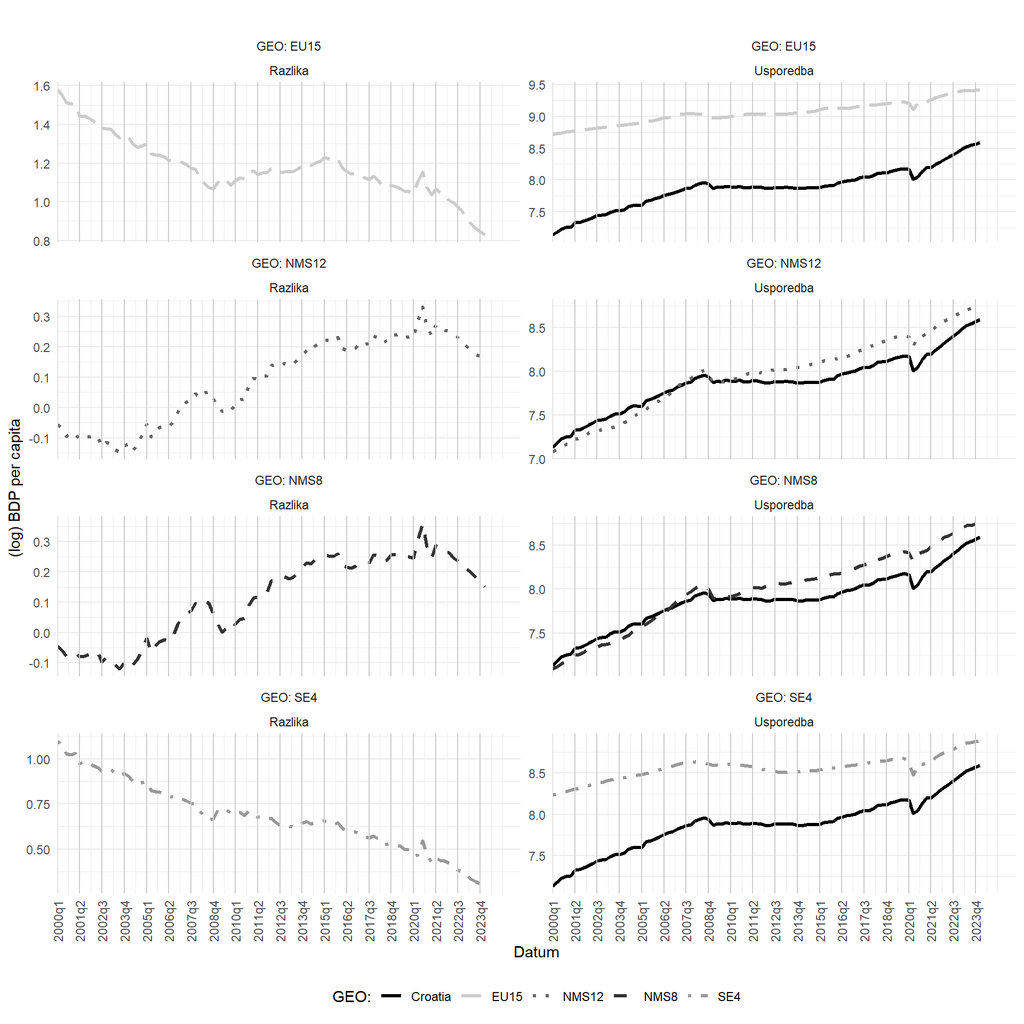

Grafikon 1 pruža vizualni prikaz kretanja razlika u BDP-u po stanovniku između Hrvatske i analiziranih skupina zemalja. U gornjem panelu prikazano je kretanje BDP-a po stanovniku za Hrvatsku i EU15. Do globalne ekonomske krize 2007. godine, Hrvatska je bilježila brži rast BDP-a, značajno se približavajući prosjeku EU15. Međutim, nakon izbijanja krize dolazi do korekcije hrvatskog BDP-a. Dok se EU15 postupno oporavlja i nastavlja s rastom, hrvatski dohodak stagnira ili čak opada. U novijem razdoblju, nakon krize uzrokovane pandemijom COVID-19, hrvatski BDP ponovno ubrzava rast, pokazujući obnovljeni trend približavanja prosjeku EU15.

Središnja dva panela prikazuju usporedbu Hrvatske s NMS8 i NMS12. Zanimljivo je da su do 2007. godine sve zemlje imale podjednake stope rasta, sugerirajući zajedničku konvergenciju. No, nakon krize, hrvatsko gospodarstvo počinje usporavati ili stagnirati, dok NMS8 i NMS12 bilježe nastavak snažnijeg rasta. To je rezultiralo rastućim jazom između BDP Hrvatske i tih dviju skupina. Ipak, u novije vrijeme, osobito nakon COVID-19 krize, primjetan je novi zamah u hrvatskom gospodarstvu, što dovodi do ublažavanja dohodovnog jaza u odnosu na NMS8 i NMS12. Zadnji panel pruža pregled odnosa Hrvatske prema SE4 skupini. Tijekom cijelog promatranog razdoblja vidljiva je stabilnija konvergencija: unatoč kratkotrajnom usporavanju tijekom krize 2007. godine, Hrvatska je kontinuirano bilježila brži rast od SE4, potvrđujući dugoročnu tendenciju konvergiranja prema toj skupini.

Iz prikazanih podataka može se zaključiti kako Hrvatska u dugom roku nastavlja konvergirati prema prosjeku EU15 i SE4. Iako je konvergencija prema NMS8 i NMS12 neko vrijeme bila zaustavljena ili usporena, osobito od 2007. do razdoblja nakon COVID-19 krize, najnoviji podatci upućuju na to da je i prema tim skupinama ponovno započeo proces približavanja. Kriza iz 2007. godine zaustavila je konvergenciju prema EU15 samo privremeno, dok je kretanje prema SE4 ostalo postojano. U novijem, postpandemijskom razdoblju, Hrvatska pokazuje pojačanu gospodarsku vitalnost, podržavajući daljnje smanjenje dohodovnih razlika u odnosu na sve analizirane skupine zemalja.

# 5 Rezultati analize

Nakon deskriptivne analize podataka, u ovom dijelu predstavljeni su rezultati statističkih testova dohodovne konvergencije između Hrvatske i skupina EU15, NMS8, NMS12 te SE4. Rezultati su dobiveni korištenjem proširenog Dickey-Fuller (ADF) testa te dvaju procjenitelja frakcijske integracije, konkretno procjenitelja koje su predložili Geweke i Porter-Hudak (1983) te Reisen (1994). Prije provođenja ovih statističkih testova, provedeni su Ljung-Box test i analiza autokorelacijske funkcije (ACF) za 20 vremenskih zaostataka kako bi se procijenila prikladnost korištene metodologije.

Tablica 1: Ljung-Box Test, Statistic

| Group | Lag 2 | Lag 4 | Lag 6 | Lag 8 | Lag 10 | Lag 12 | Lag 14 | Lag 16 | Lag 18 | Lag 20 |
| --- | --- | --- | --- | --- | --- | --- | --- | --- | --- | --- |
| EU15 | 158.38 | 275.63 | 359.29 | 419.68 | 461.89 | 491.87 | 511.27 | 525.31 | 532.73 | 536.01 |
| NMS12 | 190.71 | 370.11 | 533.94 | 680.85 | 810.78 | 923.24 | 1017.57 | 1092.36 | 1150.57 | 1195.15 |
| NMS8 | 188.34 | 362.41 | 518.27 | 655.71 | 776.15 | 880.22 | 967.00 | 1035.49 | 1088.78 | 1129.92 |
| SE4 | 171.34 | 315.25 | 434.77 | 534.52 | 617.14 | 685.72 | 739.87 | 784.09 | 816.83 | 841.24 |

S obzirom na ovako izraženu strukturu autokorelacije, konvencionalni modeli vremenskih serija koji pretpostavljaju procese kratkog pamćenja neće adekvatno uvažiti temeljnu dinamiku podataka. Stoga je nužno primijeniti modele koji mogu uzeti u obzir dugoročne ovisnosti, poput procjenitelja frakcijske integracije, koji su prikladni za modeliranje i predviđanje u prisutnosti karakteristika dugog pamćenja.

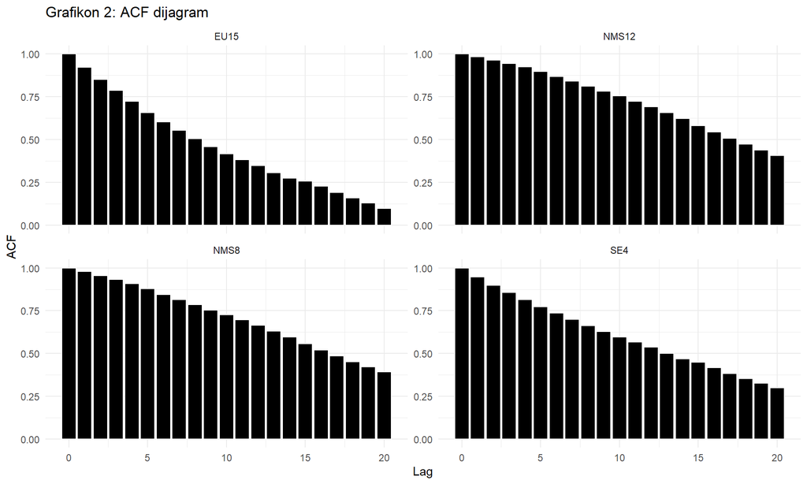

Grafikon 2 prikazuje autokorelacijske funkcije (ACF) vremenskih serija za sve četiri analizirane skupine (EU15, NMS8, NMS12, SE4). Uočava se konzistentan obrazac u svim serijama: visoka autokorelacija pri nižim zaostacima koja se postupno smanjuje s povećanjem broja zaostataka. Ovaj obrazac potvrđuje da svaku vremensku seriju karakterizira značajna autokorelacija koja se proteže preko više vremenskih zaostataka. Štoviše, sporo opadanje vrijednosti ACF dodatno potkrepljuje prisutnost dugog pamćenja i perzistentnosti u podacima.

Ovi nalazi naglašavaju važnost uvažavanja dugoročnih ovisnosti u analizi dohodovne konvergencije. Perzistentnost koju sugeriraju ACF grafikoni ukazuje na to da šokovi u dohodovnim diferencijalima između Hrvatske i odgovarajućih skupina zemalja imaju trajne učinke, te se frakcijska integracija nameće kao prikladna metoda za uvažavanje ovakve konvergencijske dinamike.

Tablica 2: ADF Test

| Group Name | Bez kons/tr | Konst | Konst/tr |
| --- | --- | --- | --- |
| RH-NMS8 | -0.4437 | -1.3338 | -0.8645 |
| RH-NMS12 | -0.4016 | -1.1247 | -0.8958 |
| RH-SE4 | -4.2296*** | -0.6393 | -2.4958 |
| RH-EU15 | -3.0241** | -1.1338 | -1.847 |

Tablica 2 prikazuje rezultate ADF testa jediničnog korijena primijenjenog na vremenske serije dohodovnih diferencijala između Hrvatske i četiri grupe zemalja. Kroz specificiranje različitih determinističkih komponenti u testnim jednadžbama, omogućeno je istraživanje različitih oblika ekonomske konvergencije: apsolutne konvergencije, uvjetne konvergencije te konvergencije prema determinističkom trendu.

Tablica 3: GPH Estimator (fdGPH) Results for Income Convergence by Bandwidth with Significance

| Group Name | Estimation Results by Bandwidth GPH d (0.4) | Estimation Results by Bandwidth GPH d (0.5) | Estimation Results by Bandwidth GPH d (0.6) | Estimation Results by Bandwidth GPH d (0.7) | Estimation Results by Bandwidth GPH d (0.8) | Estimation Results by Bandwidth GPH d (0.9) |
| --- | --- | --- | --- | --- | --- | --- |
| Croatia vs NMS8 | 1.4626*** | 1.2245*** | 1.2741*** | 1.1266*** | 1.2438*** | 1.2621*** |
| Croatia vs NMS12 | 1.5546*** | 1.2929*** | 1.2733*** | 1.1268*** | 1.244*** | 1.2152*** |
| Croatia vs SE4 | 0.8715*** | 0.8634*** | 0.9066*** | 0.9475*** | 0.9291*** | 0.9424*** |
| Croatia vs EU15 | 0.5344*** | 0.646*** | 0.7556*** | 0.8468*** | 0.857*** | 0.8882*** |

Tablica 4: GPH Estimator (fdSperio) Results for Income Convergence by Bandwidth with Significance

| Group Name | Estimation Results by Bandwidth GPH d (0.4) | Estimation Results by Bandwidth GPH d (0.5) | Estimation Results by Bandwidth GPH d (0.6) | Estimation Results by Bandwidth GPH d (0.7) | Estimation Results by Bandwidth GPH d (0.8) | Estimation Results by Bandwidth GPH d (0.9) |
| --- | --- | --- | --- | --- | --- | --- |
| Croatia vs NMS8 | 1.1778*** | 1.1778*** | 1.1778*** | 1.1778*** | 1.1778*** | 1.1778*** |
| Croatia vs NMS12 | 1.2666*** | 1.2666*** | 1.2666*** | 1.2666*** | 1.2666*** | 1.2666*** |
| Croatia vs SE4 | 0.9761*** | 0.9761*** | 0.9761*** | 0.9761*** | 0.9761*** | 0.9761*** |
| Croatia vs EU15 | 0.844*** | 0.844*** | 0.844*** | 0.844*** | 0.844*** | 0.844*** |

# 6 Zaključak

Rad je analizirao dohodovnu konvergenciju Hrvatske s različitim skupinama zemalja Europske unije koristeći analizu vremenskih serija i metode frakcijske integracije. Dok je prethodna literatura pokazala postojanje dohodovne konvergencije za neke, ali ne sve posttranzicijske europske zemlje prema prosjeku EU, ovaj rad proširio je to područje fokusirajući se na konvergencijske obrasce specifične za Hrvatsku. Dodatno, pitanje dohodovne konvergencije smješteno je u širi kontekst europskih integracijskih procesa kroz analizu međusobne konvergencije između Hrvatske i prosjeka dohotka četiri grupe zemalja: EU15, NMS8, NMS12 i SE4. Time je omogućeno zaključivanje o smjeru ekonomske i institucionalne konvergencije unutar europskih integracija te o pripadnosti Hrvatske određenim konvergencijskim klubovima.

Ovi nalazi imaju značajne implikacije za europske integracijske procese. Unatoč kasnijem pristupanju Europskoj uniji i primjeni mjera institucionalnog, pravnog i ekonomskog usklađivanja s novim članicama, Hrvatska ne pokazuje dohodovnu konvergenciju s grupama NMS8 i NMS12. To sugerira da institucionalna i pravna integracija ne rezultiraju nužno i ekonomskom konvergencijom. Čini se da Hrvatska ekonomski konvergira prema zemljama EU15 i SE4, koje karakteriziraja sporiji ili negativan gospodarski rast. Potvrda konvergencije prema SE4 ukazuje na pridruživanje Hrvatske konvergencijskom klubu južne Europe i općenito ukazuje na potrebu za politikama koje će potaknuti brži gospodarski rast i razvoj.